# Visualising simulated data

This vignette gives an overview of the ways to plot the line list and contacts data output from the `sim_linelist()` and `sim_outbreak()` functions.

Plotting can be useful to identify certain transmission dynamics and patterns in the simulated data, or just to check that the simulated data looks as expected given how the simulation was parameterised.

```r
library(simulist)
library(epiparameter)
library(incidence2)
library(epicontacts)
```

First we load the required delay distributions using the {epiparameter} package.

```r
contact_distribution <- epiparameter(
  disease = "COVID-19",
  epi_name = "contact distribution",
  prob_distribution = create_prob_distribution(
    prob_distribution = "pois",
    prob_distribution_params = c(mean = 3)
  )
)
```

```
#> Citation cannot be created as author, year, journal or title is missing
```

```r
infectious_period <- epiparameter(
  disease = "COVID-19",
  epi_name = "infectious period",
  prob_distribution = create_prob_distribution(
    prob_distribution = "gamma",
    prob_distribution_params = c(shape = 3, scale = 2)
  )
)
```

```
#> Citation cannot be created as author, year, journal or title is missing
```

```r
onset_to_hosp <- epiparameter(
  disease = "COVID-19",
  epi_name = "onset to hospitalisation",
  prob_distribution = create_prob_distribution(
    prob_distribution = "lnorm",
    prob_distribution_params = c(meanlog = 1, sdlog = 0.5)
  )
)
```

```
#> Citation cannot be created as author, year, journal or title is missing
```

```r
# get onset to death from {epiparameter} database
onset_to_death <- epiparameter_db(
  disease = "COVID-19",
  epi_name = "onset to death",
  single_epiparameter = TRUE
)
```

```
#> Using Linton N, Kobayashi T, Yang Y, Hayashi K, Akhmetzhanov A, Jung S, Yuan
#> B, Kinoshita R, Nishiura H (2020). "Incubation Period and Other
#> Epidemiological Characteristics of 2019 Novel Coronavirus Infections
#> with Right Truncation: A Statistical Analysis of Publicly Available
#> Case Data." _Journal of Clinical Medicine_. doi:10.3390/jcm9020538
#> <https://doi.org/10.3390/jcm9020538>..
#> To retrieve the citation use the 'get_citation' function
```

Setting the seed ensures we have the same output each time the vignette is rendered. When using {simulist}, setting the seed is not required unless you need to simulate the same line list multiple times.

```r
set.seed(123)
```

Using a simple line list simulation with the factory default settings:

```r
linelist <- sim_linelist(
  contact_distribution = contact_distribution,
  infectious_period = infectious_period,
  prob_infection = 0.33,
  onset_to_hosp = onset_to_hosp,
  onset_to_death = onset_to_death,
  outbreak_size = c(500, 1e4)
)
```

This line list contains 2066 cases.

## Visualising incidence of onset, hospitalisation and death

This section of the vignette is heavily based upon examples given in the [An introduction to {incidence2} package vignette](https://www.reconverse.org/incidence2/doc/incidence2.html). It is highly recommended to read the documentation supplied in the [{incidence2} package](https://CRAN.R-project.org/package=incidence2) to explore the full range of functionality.

To visualise the number of cases with onset on a particular day, the {incidence2} package, and its dedicated class (`<incidence2>`) are used for handling and plotting this data.

Currently {simulist} outputs dates that are not rounded to the nearest day, i.e. it can be half way through a day. This is not obvious as R prints dates to the nearest day by default, and only by removing the date class (using `unclass()`) can you see the decimals (as R stores dates internally as the number of days since 1970-01-01).

{simulist} stores `<Date>`s as precise doubles and not as integer days. This can be misleading as R prints `<Date>`s to the nearest day. By default {incidence2} does not aggregate to the nearest day and without specifying an `interval` in `incidence()` it will aggregate to the same precision as the data. When supplied with non-whole `<Date>`s it will produce this warning.

```r
# create incidence object
daily <- incidence(
  x = linelist,
  date_index = "date_onset"
)
```

```
#> Warning in incidence(): Non-whole <Date> columns detected. These can be
#> confusing as they are displayed without the fractional element and can also
#> cause oddities when plotting. If you are interested in daily incidence,
#> consider removing the fractional part. This can be done prior to calling
#> `incidence()` or, alternatively, by setting the argument `interval = 'day'`
#> within the call itself.
```

The `interval = "daily"` is required as {incidence2} requires rounded dates to aggregate cases per unit time and specifying the `interval` will do this automatically for us. It is possible that not every date had the onset of symptoms, resulting in some dates missing entries. This is taken care of by setting `complete_dates = TRUE`, alternatively this can be achieved by using `incidence2::complete_dates()` on the `<incidence2>` object.

```r
# create incidence object
daily <- incidence(
  x = linelist,
  date_index = "date_onset",
  interval = "daily",
  complete_dates = TRUE
)
```

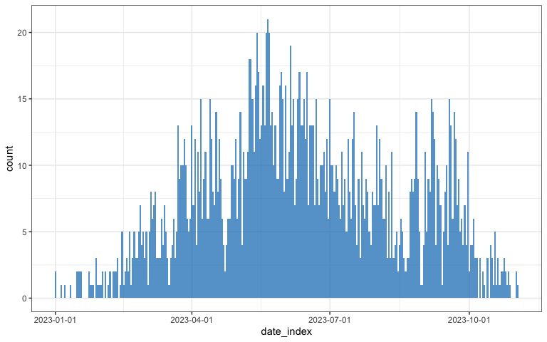

```r
plot(daily)
```

Alternatively, incidence can be plotting weekly:

```r
weekly <- incidence(linelist, date_index = "date_onset", interval = "isoweek")
```

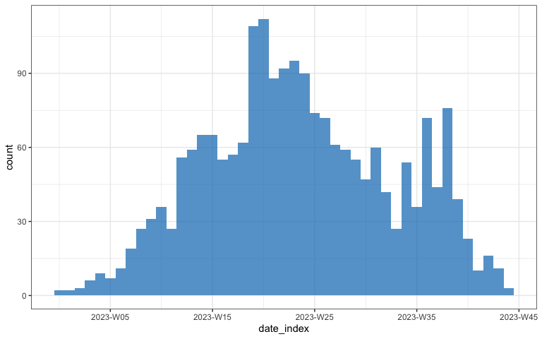

```r
plot(weekly)
```

In order to check differences between a group in the line list data, for example sex, the `<incidence2>` data object can be recreated, specifying which columns to group by.

```r
weekly <- incidence(
  linelist,
  date_index = "date_onset",
  interval = "isoweek",
  groups = "sex"
)
```

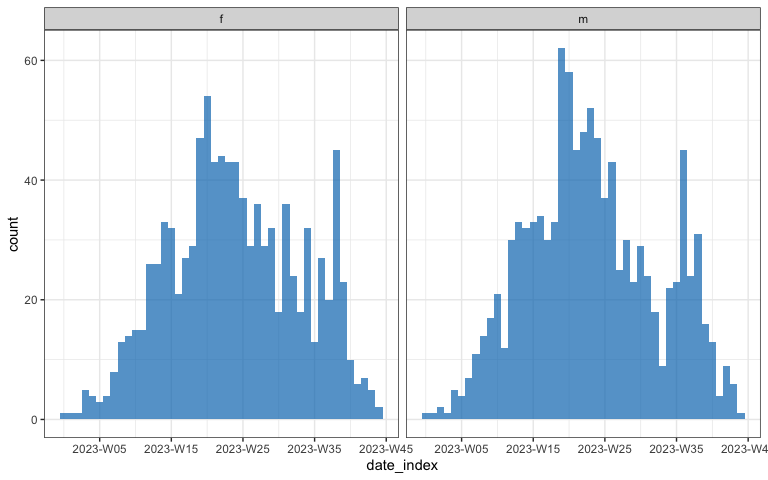

```r
plot(weekly)
```

To visualise the onset, hospitalisation and death incidence in the same plot they can be jointly specified to the `date_index` argument of `incidence2::incidence()`.

First the outcome data needs to be pivoted from long data to wide data to be input into `incidence2::incidence()`.

### Reshape line list data

#### Base R

```r
# this can also be achieved with the reshape() function but the user interface
# for that function is complicated so here we just create the columns manually
linelist$date_death <- linelist$date_outcome
linelist$date_death[linelist$outcome == "recovered"] <- NA
linelist$date_recovery <- linelist$date_outcome
linelist$date_recovery[linelist$outcome == "died"] <- NA
```

#### Tidyverse

```r
library(tidyr)
library(dplyr)
linelist <- linelist %>%
  tidyr::pivot_wider(
    names_from = outcome,
    values_from = date_outcome
  ) %>%
  dplyr::rename(
    date_death = died,
    date_recovery = recovered
  )
```

```r
daily <- incidence(
  linelist,
  date_index = c(
    onset = "date_onset",
    hospitalisation = "date_admission",
    death = "date_death"
  ),
  interval = "daily",
  groups = "sex",
  complete_dates = TRUE
)
```

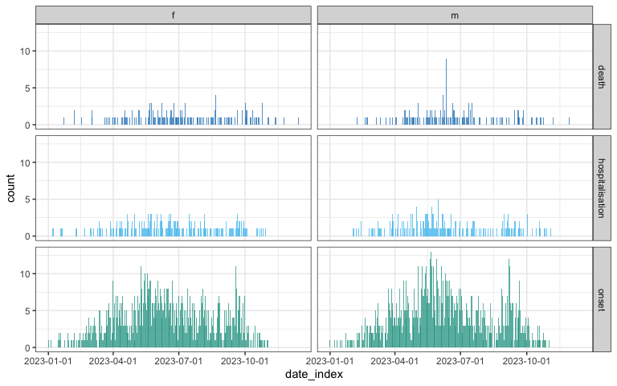

```r
plot(daily)
```

## Demographic data

Please see the Age-structured population vignette for examples of how to plot the distribution of ages within a line list data set, including age pyramids.

The plotting code in vignettes is hidden by default, click the Code button with arrow to reveal the plotting code.

## Visualising contact data

This section of the vignette is based upon examples from the [{epicontacts} R package documentation](https://www.repidemicsconsortium.org/epicontacts/index.html) and the examples provided in the [The Epidemiological R Handbook chapter on transmission chains](https://www.epirhandbook.com/en/new_pages/transmission_chains.html). We recommend going to the documentation of the {epicontacts} R package to see the all plotting and data wrangling functionality.

Just as we utilised the `<incidence2>` class from the {incidence2} package to handle and plot incidence data, we are going to use the `<epicontacts>` class from the {epicontacts} R package to handle and plot epidemiological contact data.

The benefit of using {epicontacts} is the same as {incidence2}, in the fact that a default plotting method is supplied by the package.

*Advanced*

Additionally, {epicontacts} provides access to network plotting from JavaScript libraries via the [{visNetwork}](https://CRAN.R-project.org/package=visNetwork) and [{threejs}](https://CRAN.R-project.org/package=threejs) R packages.

The {epicontacts} function `make_epicontacts()` requires both the line list and contacts table, so we will run the `sim_outbreak()` function to produce both. We will use the same epidemiological delay distributions that we used to simulate a line list above, but reduce the mean number of contacts in the contact distribution to 2.

```r
contact_distribution <- epiparameter(
  disease = "COVID-19",
  epi_name = "contact distribution",
  prob_distribution = create_prob_distribution(
    prob_distribution = "pois",
    prob_distribution_params = c(mean = 2)
  )
)
```

```
#> Citation cannot be created as author, year, journal or title is missing
```

```r
set.seed(1)
outbreak <- sim_outbreak(
  contact_distribution = contact_distribution,
  infectious_period = infectious_period,
  prob_infection = 0.5,
  onset_to_hosp = onset_to_hosp,
  onset_to_death = onset_to_death
)
head(outbreak$linelist)
```

```
#>   id              case_name case_type sex age date_onset date_reporting
#> 1  1           Kevin Pullen suspected   m   1 2023-01-01     2023-01-01
#> 2  2 Carisa Flores-Gonzalez confirmed   f  29 2023-01-01     2023-01-01
#> 3  3       Maazin el-Othman confirmed   m  78 2023-01-02     2023-01-02
#> 4  5       Faisal el-Vaziri suspected   m  70 2023-01-05     2023-01-05
#> 5  6           Lynsey Duron confirmed   f  28 2023-01-02     2023-01-02
#> 6  8         Lilibeth Black confirmed   f  61 2023-01-04     2023-01-04
#>   date_admission   outcome date_outcome date_first_contact date_last_contact
#> 1     2023-01-03      died   2023-01-18               <NA>              <NA>
#> 2     2023-01-03      died   2023-02-09         2022-12-30        2023-01-08
#> 3           <NA> recovered         <NA>         2022-12-31        2023-01-05
#> 4     2023-01-08 recovered         <NA>         2022-12-31        2023-01-04
#> 5     2023-01-06 recovered         <NA>         2022-12-30        2023-01-03
#> 6           <NA> recovered         <NA>         2022-12-29        2023-01-06
#>   ct_value
#> 1       NA
#> 2     25.8
#> 3     24.9
#> 4       NA
#> 5     24.5
#> 6     26.4
```

```r
head(outbreak$contacts)
```

```
#>                     from                     to age sex date_first_contact
#> 1           Kevin Pullen Carisa Flores-Gonzalez  29   f         2022-12-30
#> 2           Kevin Pullen       Maazin el-Othman  78   m         2022-12-31
#> 3 Carisa Flores-Gonzalez         Katelyn Catlin  22   f         2022-12-30
#> 4 Carisa Flores-Gonzalez       Faisal el-Vaziri  70   m         2022-12-31
#> 5       Maazin el-Othman           Lynsey Duron  28   f         2022-12-30
#> 6       Maazin el-Othman        Amaani al-Gaber  37   f         2022-12-28
#>   date_last_contact was_case         status
#> 1        2023-01-08     TRUE           case
#> 2        2023-01-05     TRUE           case
#> 3        2023-01-03    FALSE under_followup
#> 4        2023-01-04     TRUE           case
#> 5        2023-01-03     TRUE           case
#> 6        2023-01-02    FALSE under_followup
```

Using the line list and contacts data simulated we can create the `<epicontacts>` object.

```r
epicontacts <- make_epicontacts(
  linelist = outbreak$linelist,
  contacts = outbreak$contacts,
  id = "case_name",
  from = "from",
  to = "to",
  directed = TRUE
)
```

The `<epicontacts>` object comes with a custom printing feature to see the data.

```r
epicontacts
```

```
#>
#> /// Epidemiological Contacts //
#>
#>   // class: epicontacts
#>   // 12 cases in linelist; 21 contacts;  directed
#>
#>   // linelist
#>
#> # A tibble: 12 × 13
#>    id        id.1 case_type sex     age date_onset date_reporting date_admission
#>    <chr>    <int> <chr>     <chr> <int> <date>     <date>         <date>
#>  1 Kevin P…     1 suspected m         1 2023-01-01 2023-01-01     2023-01-03
#>  2 Carisa …     2 confirmed f        29 2023-01-01 2023-01-01     2023-01-03
#>  3 Maazin …     3 confirmed m        78 2023-01-02 2023-01-02     NA
#>  4 Faisal …     5 suspected m        70 2023-01-05 2023-01-05     2023-01-08
#>  5 Lynsey …     6 confirmed f        28 2023-01-02 2023-01-02     2023-01-06
#>  6 Lilibet…     8 confirmed f        61 2023-01-04 2023-01-04     NA
#>  7 Kaleb N…    11 confirmed m        86 2023-01-04 2023-01-04     NA
#>  8 Collin …    12 confirmed m        71 2023-01-06 2023-01-06     2023-01-08
#>  9 Marquaj…    13 confirmed f        51 2023-01-07 2023-01-07     NA
#> 10 Francis…    19 probable  m        50 2023-01-09 2023-01-09     NA
#> 11 Kevin W…    21 suspected m        20 2023-01-11 2023-01-11     NA
#> 12 Sean Sh…    22 confirmed m        24 2023-01-11 2023-01-11     NA
#> # ℹ 5 more variables: outcome <chr>, date_outcome <date>,
#> #   date_first_contact <date>, date_last_contact <date>, ct_value <dbl>
#>
#>   // contacts
#>
#> # A tibble: 21 × 8
#>    from   to      age sex   date_first_contact date_last_contact was_case status
#>    <chr>  <chr> <int> <chr> <date>             <date>            <lgl>    <chr>
#>  1 Kevin… Cari…    29 f     2022-12-30         2023-01-08        TRUE     case
#>  2 Kevin… Maaz…    78 m     2022-12-31         2023-01-05        TRUE     case
#>  3 Caris… Kate…    22 f     2022-12-30         2023-01-03        FALSE    under…
#>  4 Caris… Fais…    70 m     2022-12-31         2023-01-04        TRUE     case
#>  5 Maazi… Lyns…    28 f     2022-12-30         2023-01-03        TRUE     case
#>  6 Maazi… Amaa…    37 f     2022-12-28         2023-01-02        FALSE    under…
#>  7 Maazi… Lili…    61 f     2022-12-29         2023-01-06        TRUE     case
#>  8 Faisa… Jorg…    46 m     2023-01-01         2023-01-06        FALSE    lost_…
#>  9 Lynse… Jacy…    67 f     2022-12-30         2023-01-05        FALSE    lost_…
#> 10 Lilib… Kale…    86 m     2023-01-02         2023-01-07        TRUE     case
#> # ℹ 11 more rows
```

To plot the contact network we can use the plotting method that is supplied by {epicontacts} and will be automatically recognised if the {epicontacts} package is loaded (as done above with `library(epicontacts)`).

If you are viewing this vignette on the web (or on a web browser) the graph below is interactive and will allow you to highlight individuals in the network using the drop-down menu, to zoom in and out of the plot by scrolling, and to move the network using the mouse to drag and drop.

```r
plot(epicontacts)
```

[interactive chart not shown]

There is also the option to plot the contacts network in 3D using the `epicontacts::graph3D()`.

By default the outbreak simulated by `sim_outbreak()` contains contacts of cases that were not infected. These are shown in the previous network plot by terminal nodes that do not pass on infection to other individuals (note that terminal nodes can also be infected individuals that did not infect anybody else, either due to not have any contacts or due to the probabilistic nature of infection transmission). Here we show how to subset the contacts table in order to only plot the transmission network of cases from the outbreak.

### Subset contact network to transmission network

#### Base R

```r
outbreak$contacts <- outbreak$contacts[outbreak$contacts$was_case, ]
```

#### Tidyverse

```r
library(dplyr)
outbreak$contacts <- outbreak$contacts %>% # nolint one_call_pipe_linter
  dplyr::filter(was_case)
```

```r
head(outbreak$linelist)
```

```
#>   id              case_name case_type sex age date_onset date_reporting
#> 1  1           Kevin Pullen suspected   m   1 2023-01-01     2023-01-01
#> 2  2 Carisa Flores-Gonzalez confirmed   f  29 2023-01-01     2023-01-01
#> 3  3       Maazin el-Othman confirmed   m  78 2023-01-02     2023-01-02
#> 4  5       Faisal el-Vaziri suspected   m  70 2023-01-05     2023-01-05
#> 5  6           Lynsey Duron confirmed   f  28 2023-01-02     2023-01-02
#> 6  8         Lilibeth Black confirmed   f  61 2023-01-04     2023-01-04
#>   date_admission   outcome date_outcome date_first_contact date_last_contact
#> 1     2023-01-03      died   2023-01-18               <NA>              <NA>
#> 2     2023-01-03      died   2023-02-09         2022-12-30        2023-01-08
#> 3           <NA> recovered         <NA>         2022-12-31        2023-01-05
#> 4     2023-01-08 recovered         <NA>         2022-12-31        2023-01-04
#> 5     2023-01-06 recovered         <NA>         2022-12-30        2023-01-03
#> 6           <NA> recovered         <NA>         2022-12-29        2023-01-06
#>   ct_value
#> 1       NA
#> 2     25.8
#> 3     24.9
#> 4       NA
#> 5     24.5
#> 6     26.4
```

```r
head(outbreak$contacts)
```

```
#>                     from                     to age sex date_first_contact
#> 1           Kevin Pullen Carisa Flores-Gonzalez  29   f         2022-12-30
#> 2           Kevin Pullen       Maazin el-Othman  78   m         2022-12-31
#> 3 Carisa Flores-Gonzalez       Faisal el-Vaziri  70   m         2022-12-31
#> 4       Maazin el-Othman           Lynsey Duron  28   f         2022-12-30
#> 5       Maazin el-Othman         Lilibeth Black  61   f         2022-12-29
#> 6         Lilibeth Black        Kaleb Natarelli  86   m         2023-01-02
#>   date_last_contact was_case status
#> 1        2023-01-08     TRUE   case
#> 2        2023-01-05     TRUE   case
#> 3        2023-01-04     TRUE   case
#> 4        2023-01-03     TRUE   case
#> 5        2023-01-06     TRUE   case
#> 6        2023-01-07     TRUE   case
```

```r
epicontacts <- make_epicontacts(
  linelist = outbreak$linelist,
  contacts = outbreak$contacts,
  id = "case_name",
  from = "from",
  to = "to",
  directed = TRUE
)
```

```r
epicontacts
```

```
#>
#> /// Epidemiological Contacts //
#>
#>   // class: epicontacts
#>   // 12 cases in linelist; 11 contacts;  directed
#>
#>   // linelist
#>
#> # A tibble: 12 × 13
#>    id        id.1 case_type sex     age date_onset date_reporting date_admission
#>    <chr>    <int> <chr>     <chr> <int> <date>     <date>         <date>
#>  1 Kevin P…     1 suspected m         1 2023-01-01 2023-01-01     2023-01-03
#>  2 Carisa …     2 confirmed f        29 2023-01-01 2023-01-01     2023-01-03
#>  3 Maazin …     3 confirmed m        78 2023-01-02 2023-01-02     NA
#>  4 Faisal …     5 suspected m        70 2023-01-05 2023-01-05     2023-01-08
#>  5 Lynsey …     6 confirmed f        28 2023-01-02 2023-01-02     2023-01-06
#>  6 Lilibet…     8 confirmed f        61 2023-01-04 2023-01-04     NA
#>  7 Kaleb N…    11 confirmed m        86 2023-01-04 2023-01-04     NA
#>  8 Collin …    12 confirmed m        71 2023-01-06 2023-01-06     2023-01-08
#>  9 Marquaj…    13 confirmed f        51 2023-01-07 2023-01-07     NA
#> 10 Francis…    19 probable  m        50 2023-01-09 2023-01-09     NA
#> 11 Kevin W…    21 suspected m        20 2023-01-11 2023-01-11     NA
#> 12 Sean Sh…    22 confirmed m        24 2023-01-11 2023-01-11     NA
#> # ℹ 5 more variables: outcome <chr>, date_outcome <date>,
#> #   date_first_contact <date>, date_last_contact <date>, ct_value <dbl>
#>
#>   // contacts
#>
#> # A tibble: 11 × 8
#>    from   to      age sex   date_first_contact date_last_contact was_case status
#>    <chr>  <chr> <int> <chr> <date>             <date>            <lgl>    <chr>
#>  1 Kevin… Cari…    29 f     2022-12-30         2023-01-08        TRUE     case
#>  2 Kevin… Maaz…    78 m     2022-12-31         2023-01-05        TRUE     case
#>  3 Caris… Fais…    70 m     2022-12-31         2023-01-04        TRUE     case
#>  4 Maazi… Lyns…    28 f     2022-12-30         2023-01-03        TRUE     case
#>  5 Maazi… Lili…    61 f     2022-12-29         2023-01-06        TRUE     case
#>  6 Lilib… Kale…    86 m     2023-01-02         2023-01-07        TRUE     case
#>  7 Lilib… Coll…    71 m     2022-12-31         2023-01-12        TRUE     case
#>  8 Lilib… Marq…    51 f     2023-01-01         2023-01-07        TRUE     case
#>  9 Marqu… Fran…    50 m     2023-01-05         2023-01-09        TRUE     case
#> 10 Marqu… Kevi…    20 m     2023-01-04         2023-01-10        TRUE     case
#> 11 Franc… Sean…    24 m     2023-01-03         2023-01-12        TRUE     case
```

```r
plot(epicontacts)
```

[interactive chart not shown]

## Visualising other line list information

If there are other aspects of line list data that can be plotted and you would like to them added to this vignette please make an [issue](https://github.com/epiverse-trace/simulist/issues) or [pull request](https://github.com/epiverse-trace/simulist/pulls).